# Functional Diversity Indices

We are going to calculate some functional diversity indices for some grassland plant communities. We will primarily be using the “FD” library, but will also write a function to calculate univariate FDvar from Mason 2003 JVS.

First let’s read in our community composition and functional trait datasets

```r
setwd('U:/LOCKED/grassland_data/')
comm=as.data.frame(read.csv('community_comp.csv',head=T,row.names=1))
traits=as.data.frame(read.csv('trait_by_species.csv',head=T,row.names=1))
traits=traits[,-c(1,19:20)]
head(traits)
```

```
##        GF Origin     Seed     Ht    LDMC LeafCN       MD   Area   SLA
## AMSMEN  F      N 0.002370 0.7597 0.07601  16.36 0.001283 0.3657 2.361
## AVENA   G      E 0.015665 1.5058 0.07937  18.54 0.003720 0.8165 2.539
## BRADIS  G      E 0.003989 0.9708 0.14258  23.22 0.001539 0.4884 2.492
## BRIMIN  G      E 0.003882 1.1081 0.08933  16.06 0.002963 0.7088 2.516
## BRODIA  G      E 0.010098 1.1123 0.07292  19.68 0.004532 0.9236 2.517
## BROHOR  G      E 0.002228 1.0737 0.07982  16.34 0.002771 0.7362 2.548
##            RMF   Total    RGR    Dens   DiamC  SRLC  SRLF  PropF
## AMSMEN 0.07826 0.01909 0.5950 0.02898 0.28556 3.624 4.781 0.2836
## AVENA  0.10248 0.09035 0.5655 0.02706 0.14457 3.639 4.602 0.2976
## BRADIS 0.10897 0.01565 0.5068 0.02780 0.08279 3.704 4.738 0.3003
## BRIMIN 0.14788 0.03888 0.6418 0.02892 0.10926 3.730 4.728 0.2980
## BRODIA 0.17138 0.04552 0.5306 0.02758 0.13830 3.699 4.755 0.2986
## BROHOR 0.14929 0.02690 0.6390 0.02565 0.09691 3.747 4.782 0.3000
```

Notice that we have a mix of continuous and categorical traits.

Now let’s run the primary function of the “FD” library, dbFD(). The default is to provide several FD indices (look at the help menu for descriptions).

```r
library(FD)
multiFD=dbFD(traits,comm)
```

```
## Species x species distance matrix was not Euclidean. 'sqrt' correction was applied.
## FRic: Dimensionality reduction was required. The last 25 PCoA axes (out of 29 in total) were removed.
```

```
## FRic: Quality of the reduced-space representation (based on corrected distance matrix) = 0.6338
```

```r
multiFD
```

```
## $nbsp
##  C111 C111E C111N  C121  F112  F113  F114  F122  F132  F134  F141  F142
##    17     9    11     5    11     7    13    11    15     7    10    12
##  F144  F151  F161    F2    H7    H9 K111A K111C K111E K111F K111G K111H
##     6    14     9     8    12     9    12    14    16    14     9    15
## K121N K121S  L111 L111B L111D L111E L111N L111S  L121 L121C L121N  P111
##    21    15    13    19    11    17    11    13    11    12    16     9
##  P112  P113  P114  P121  P131  P221  SC12  SC14 SH111 SH121 SH131 SH141
##     9    10     9    11    11     8    12    14     9    10    14     6
## USC14
##    11
##
## $sing.sp
##  C111 C111E C111N  C121  F112  F113  F114  F122  F132  F134  F141  F142
##    17     9    11     5    11     7    13    11    15     7    10    12
##  F144  F151  F161    F2    H7    H9 K111A K111C K111E K111F K111G K111H
##     6    14     9     8    12     9    12    14    16    14     9    15
## K121N K121S  L111 L111B L111D L111E L111N L111S  L121 L121C L121N  P111
##    21    15    13    19    11    17    11    13    11    12    16     9
##  P112  P113  P114  P121  P131  P221  SC12  SC14 SH111 SH121 SH131 SH141
##     9    10     9    11    11     8    12    14     9    10    14     6
## USC14
##    11
##
## $FRic
##      C111     C111E     C111N      C121      F112      F113      F114
## 2.684e-03 3.773e-04 1.474e-03 8.237e-06 1.605e-03 2.184e-05 2.431e-03
##      F122      F132      F134      F141      F142      F144      F151
## 2.050e-03 2.468e-03 4.251e-04 9.937e-04 7.825e-04 9.980e-04 3.183e-03
##      F161        F2        H7        H9     K111A     K111C     K111E
## 7.529e-04 5.027e-04 2.717e-03 9.616e-04 2.286e-03 3.949e-03 3.397e-03
##     K111F     K111G     K111H     K121N     K121S      L111     L111B
## 1.071e-03 5.673e-04 3.257e-03 3.078e-03 3.568e-03 1.483e-03 3.443e-03
##     L111D     L111E     L111N     L111S      L121     L121C     L121N
## 3.428e-03 2.756e-03 5.161e-04 1.257e-03 3.269e-03 7.842e-04 2.013e-03
##      P111      P112      P113      P114      P121      P131      P221
## 3.909e-04 1.440e-03 2.131e-03 5.556e-04 3.031e-03 3.045e-03 1.719e-04
##      SC12      SC14     SH111     SH121     SH131     SH141     USC14
## 1.083e-03 3.104e-03 1.732e-03 7.229e-04 2.784e-03 7.387e-05 3.137e-03
##
```

[output cut: 141 more lines]

```
## L121N 0.1364 0.05240 0.6602 0.02800 0.1880 3.506 4.705 0.2977
## P111  0.1252 0.06226 0.6244 0.02637 0.3051 3.126 4.618 0.2990
## P112  0.1107 0.05080 0.5776 0.02711 0.2166 3.364 4.654 0.2992
## P113  0.1173 0.06966 0.6059 0.02684 0.2212 3.408 4.625 0.2981
## P114  0.1486 0.03477 0.6080 0.02810 0.1432 3.642 4.720 0.2971
## P121  0.1354 0.05713 0.6451 0.02694 0.2373 3.350 4.673 0.2986
## P131  0.1293 0.05706 0.6196 0.02672 0.2070 3.439 4.658 0.2985
## P221  0.1419 0.05464 0.6122 0.02641 0.1626 3.579 4.690 0.2982
## SC12  0.1205 0.03687 0.5918 0.02698 0.1997 3.436 4.694 0.2992
## SC14  0.1246 0.06449 0.6512 0.02823 0.2502 3.337 4.669 0.2982
## SH111 0.1117 0.05258 0.5947 0.02715 0.2587 3.254 4.646 0.2992
## SH121 0.1233 0.06774 0.6366 0.02801 0.1467 3.645 4.694 0.2967
## SH131 0.1320 0.03554 0.6109 0.02673 0.1835 3.549 4.729 0.2978
## SH141 0.1386 0.05667 0.5989 0.02660 0.1707 3.561 4.671 0.2979
## USC14 0.1420 0.04399 0.6351 0.02647 0.2182 3.426 4.691 0.2984
```

Note that when the dbFD function was applied, there were messages saying “Dimensionality reduction was required” and “Quality of reduced-space representation = 0.634”. The number of trait dimensions was reduced using a PCoA (would have been a PCA if all traits were continuous), and represented ~63% of the variance in the raw trait data.

Let’s look at some relationships among FD indices.

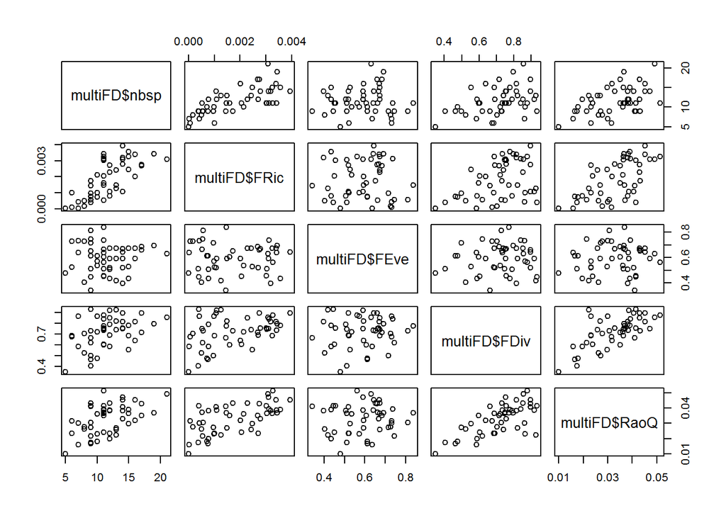

```r
pairs(~multiFD$nbsp+multiFD$FRic+multiFD$FEve+multiFD$FDiv+multiFD$RaoQ)
```

What patterns do you see?

Typically you would want to standardize your trait data first. If you have traits that naturally vary in their range, variables with greater ranges will have larger effects on the calculation of FD.

```r
zTrans=function(x){
  return((x-mean(x,na.rm=T))/sd(x,na.rm=T))
}
zTraits=apply(traits[,-c(1:2)],2,zTrans)
zTraits=cbind(traits[,1:2],zTraits)#adding back in our categorical traits
zFD=dbFD(zTraits,comm)
```

```
## Species x species distance matrix was not Euclidean. 'sqrt' correction was applied.
## FRic: Dimensionality reduction was required. The last 25 PCoA axes (out of 29 in total) were removed.
```

```
## FRic: Quality of the reduced-space representation (based on corrected distance matrix) = 0.6338
```

Cramming all traits together to calculated a single FD value loses information on specific trait patterns. Let’s calculate the indices for a single trait, height, across all communities, a la Mason et al. 2005.

```r
height=as.data.frame(traits$Ht)
row.names(height)=row.names(traits)
heightFD=dbFD(height,comm)
```

```
## FRic: Only one continuous trait or dimension in 'x'. FRic was measured as the range, NOT as the convex hull volume.
## FDiv: Cannot not be computed when 'x' contains one single continuous trait or dimension.
```

```r
heightFD
```

```
## $nbsp
##  C111 C111E C111N  C121  F112  F113  F114  F122  F132  F134  F141  F142
##    17     9    11     5    11     7    13    11    15     7    10    12
##  F144  F151  F161    F2    H7    H9 K111A K111C K111E K111F K111G K111H
##     6    14     9     8    12     9    12    14    16    14     9    15
## K121N K121S  L111 L111B L111D L111E L111N L111S  L121 L121C L121N  P111
##    21    15    13    19    11    17    11    13    11    12    16     9
##  P112  P113  P114  P121  P131  P221  SC12  SC14 SH111 SH121 SH131 SH141
##     9    10     9    11    11     8    12    14     9    10    14     6
## USC14
##    11
##
## $sing.sp
##  C111 C111E C111N  C121  F112  F113  F114  F122  F132  F134  F141  F142
##    14     9    11     5    11     7    11    11    13     6     9    11
##  F144  F151  F161    F2    H7    H9 K111A K111C K111E K111F K111G K111H
##     6    12     9     8    11     9    11    13    13    12     9    15
## K121N K121S  L111 L111B L111D L111E L111N L111S  L121 L121C L121N  P111
##    15    13    11    18    10    16    11    13     9    11    15     9
##  P112  P113  P114  P121  P131  P221  SC12  SC14 SH111 SH121 SH131 SH141
##     9     8     9    10    10     8     9    11     9    10    13     6
## USC14
##    10
##
## $FRic
##  C111 C111E C111N  C121  F112  F113  F114  F122  F132  F134  F141  F142
## 4.099 3.066 3.257 3.066 3.857 3.066 3.857 3.857 3.857 3.857 4.099 4.099
##  F144  F151  F161    F2    H7    H9 K111A K111C K111E K111F K111G K111H
## 3.857 4.099 4.099 3.857 3.857 3.857 2.273 2.539 2.661 3.857 2.864 3.857
## K121N K121S  L111 L111B L111D L111E L111N L111S  L121 L121C L121N  P111
## 3.153 4.099 2.531 2.539 2.297 2.531 3.857 4.099 2.297 3.857 3.257 3.857
##  P112  P113  P114  P121  P131  P221  SC12  SC14 SH111 SH121 SH131 SH141
## 3.857 3.857 3.257 3.257 3.857 3.857 3.257 3.857 3.857 3.857 4.099 3.857
## USC14
## 3.257
##
## $qual.FRic
## [1] 1
##
## $FEve
```

[output cut: 71 more lines]

```
## L121N    1.0372
## P111     0.7885
## P112     0.9258
## P113     1.1085
## P114     1.0619
## P121     0.9334
## P131     1.0351
## P221     1.1419
## SC12     0.8737
## SC14     0.9611
## SH111    0.8273
## SH121    1.3161
## SH131    0.9473
## SH141    1.1576
## USC14    0.9063
```

Note that we are missing FDiv, which can’t be calculated on a single trait. The univariate analog to FDiv is FDvar (Mason 2003 JVS). See Butterfield and Suding 2013 as well.

We need to create our own FDvar function. I have done this and saved it as a .R file in our working directory. You can open it up and check it out, or just type in ‘FDvar’ AFTER running the source() line below. This is a convenient way of keeping your code organized, especially for functions that you may use frequently.

```r
source('U:/LOCKED/grassland_data/FDvar_fxn.R')

heightFDvar=apply(comm,1,FDvar,traits$Ht)
heightFDvar
```

```
##    C111   C111E   C111N    C121    F112    F113    F114    F122    F132
## 0.14907 0.04797 0.08950 0.03967 0.17281 0.04045 0.08246 0.08780 0.13127
##    F134    F141    F142    F144    F151    F161      F2      H7      H9
## 0.16426 0.12327 0.07189 0.14751 0.10427 0.06019 0.10202 0.06076 0.12284
##   K111A   K111C   K111E   K111F   K111G   K111H   K121N   K121S    L111
## 0.07363 0.06810 0.06323 0.06233 0.06826 0.08488 0.11084 0.07898 0.06205
##   L111B   L111D   L111E   L111N   L111S    L121   L121C   L121N    P111
## 0.05475 0.05988 0.06932 0.11023 0.05165 0.08771 0.11651 0.08509 0.08659
##    P112    P113    P114    P121    P131    P221    SC12    SC14   SH111
## 0.12128 0.19184 0.03451 0.08121 0.13119 0.07924 0.06312 0.11623 0.10270
##   SH121   SH131   SH141   USC14
## 0.05770 0.10361 0.12582 0.09054
```

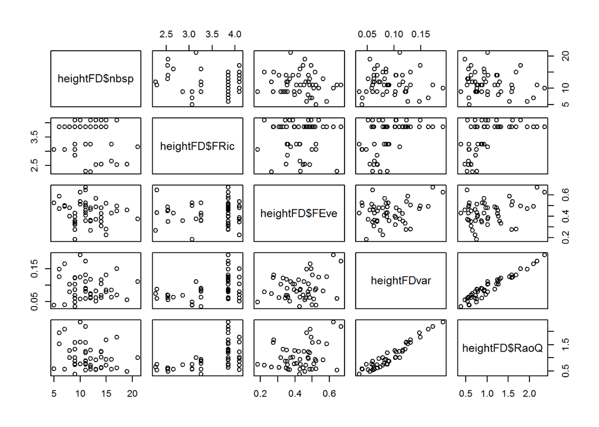

```r
pairs(~heightFD$nbsp+heightFD$FRic+heightFD$FEve+heightFDvar+heightFD$RaoQ)
```